## 1. Code for reading in the dataset and/or processing the data

```r
#Loading libraries
#------------------------
library("data.table")
library("ggplot2")
#------------------------

#Loading and preprocessing the data
fileUrl <- "https://d396qusza40orc.cloudfront.net/repdata%2Fdata%2Factivity.zip"
download.file(fileUrl, destfile = paste0(getwd(), '/repdata%2Fdata%2Factivity.zip'))
unzip("repdata%2Fdata%2Factivity.zip",exdir = "data")
activityDT <- read.csv("./data/activity.csv")

# Removing NAs from activityDT
activityDT.RemovedNAs <- activityDT[!is.na(activityDT$steps), ]
# Removing any date factors for NA
activityDT.RemovedNAs$date <- factor(activityDT.RemovedNAs$date)
```

## What is mean total number of steps taken per day?

### 2. Histogram of the total number of steps taken each day

```r
TotalofSteps <- as.data.frame(tapply(activityDT.RemovedNAs$steps, as.factor(activityDT.RemovedNAs$date), sum))
names(TotalofSteps) <- c("Steps")
```

### 3. If you do not understand the difference between a histogram and a barplot, research the difference between them. Make a histogram of the total number of steps taken each day.

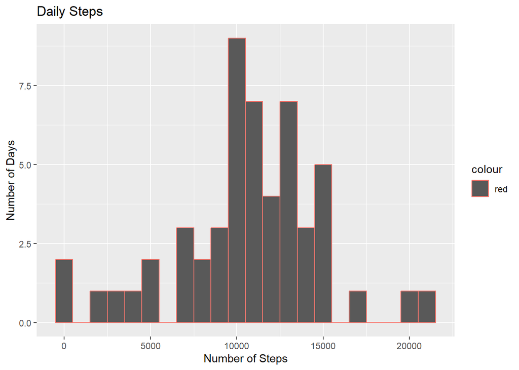

```r
# FIG1
qplot(TotalofSteps$Steps, geom="histogram", ylab="Number of Days", xlab="Number of Steps", color = "red", binwidth = 1000, main = "Daily Steps")
```

### 4. Calculate the Mean and median number of steps taken each day

```r
print(mean(TotalofSteps$Steps), row.names = FALSE)
```

```
## [1] 10766.19
```

```r
print(median(TotalofSteps$Steps), row.names = FALSE)
```

```
## [1] 10765
```

## What is the average daily activity pattern?

### 5. Make a time series plot of the 5-minute interval (x-axis) and the average number of steps taken, averaged across all days (y-axis)

```r
meanStepsPerInterval <- tapply(activityDT.RemovedNAs$steps, as.factor(activityDT.RemovedNAs$interval), mean)
meanStepsPerInterval <- as.data.frame(meanStepsPerInterval)
meanStepsPerInterval$interval <- rownames(meanStepsPerInterval)
```

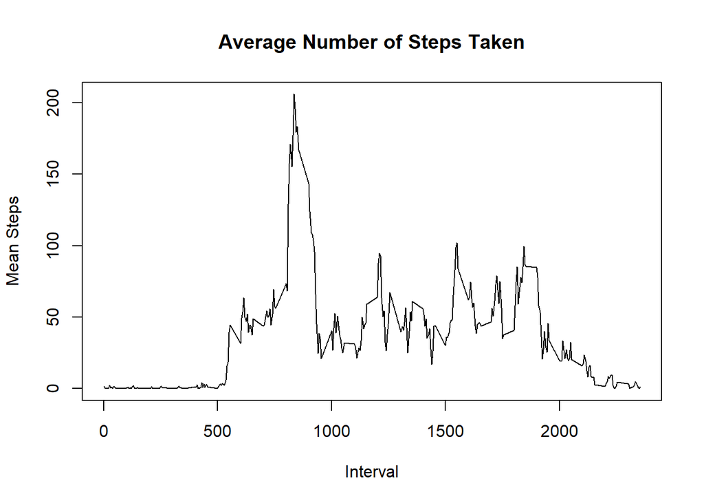

```r
# FIG2
plot(meanStepsPerInterval$interval, meanStepsPerInterval$mean, type = 'l', ylab = "Mean Steps", xlab = "Interval", main = "Average Number of Steps Taken")
```

### 6. The 5-minute interval that, on average, contains the maximum number of steps

```r
meanStepsPerInterval[meanStepsPerInterval$mean == max(meanStepsPerInterval$mean), ][1]
```

```
##     meanStepsPerInterval
## 835             206.1698
```

### 7. Code to describe and show a strategy for imputing missing data

```r
# total number of missing values in the dataset
nrow(activityDT[is.na(activityDT$steps), ])
```

```
## [1] 2304
```

```r
# For all data points with NA steps, impute the average number of steps for that interval.
meanStepsPerInterval$interval <- as.integer(meanStepsPerInterval$interval)
activityDT.filledIn <- merge(activityDT, meanStepsPerInterval, by = "interval")
activityDT.filledIn$steps[is.na(activityDT.filledIn$steps)] <- activityDT.filledIn$meanStepsPerInterval[is.na(activityDT.filledIn$steps)]
```

### 8. Histogram of the total number of steps taken each day after missing values are imputed

```r
TotalofSteps.filledIn <- as.data.frame(tapply(activityDT.filledIn$steps, as.factor(activityDT.filledIn$date), sum))
names(TotalofSteps.filledIn) <- c("Steps")
```

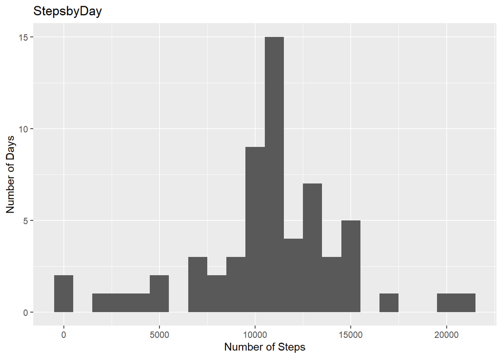

```r
# FIG3
qplot(TotalofSteps.filledIn$Steps, geom="histogram", ylab="Number of Days", xlab="Number of Steps", binwidth = 1000, main = "StepsbyDay")
```

## Calculate the mean and median total number of steps per day:

```r
print(mean(TotalofSteps.filledIn$Steps), row.names = FALSE)
```

```
## [1] 10766.19
```

```r
print(median(TotalofSteps.filledIn$Steps), row.names = FALSE)
```

```
## [1] 10766.19
```

```r
activityDT <- data.table::fread(input = "data/activity.csv")
activityDT[, date := as.Date(activityDT$date)]
activityDT[, `Day of Week`:= weekdays(activityDT$date)]
activityDT$`weekday or weekend` <- ifelse(activityDT$`Day of Week` %in% c('Saturday', 'Sunday'), 'Weekend', 'Weekday')
head(activityDT, 10)
```

```
##     steps       date interval Day of Week weekday or weekend
##  1:    NA 2012-10-01        0      星期一            Weekday
##  2:    NA 2012-10-01        5      星期一            Weekday
##  3:    NA 2012-10-01       10      星期一            Weekday
##  4:    NA 2012-10-01       15      星期一            Weekday
##  5:    NA 2012-10-01       20      星期一            Weekday
##  6:    NA 2012-10-01       25      星期一            Weekday
##  7:    NA 2012-10-01       30      星期一            Weekday
##  8:    NA 2012-10-01       35      星期一            Weekday
##  9:    NA 2012-10-01       40      星期一            Weekday
## 10:    NA 2012-10-01       45      星期一            Weekday
```

```r
activityDT[is.na(steps), "steps"] <- activityDT[, c(lapply(.SD, median, na.rm = TRUE)), .SDcols = c("steps")]
IntervalDT <- activityDT[, c(lapply(.SD, mean, na.rm = TRUE)), .SDcols = c("steps"), by = .(interval, `weekday or weekend`)]
```

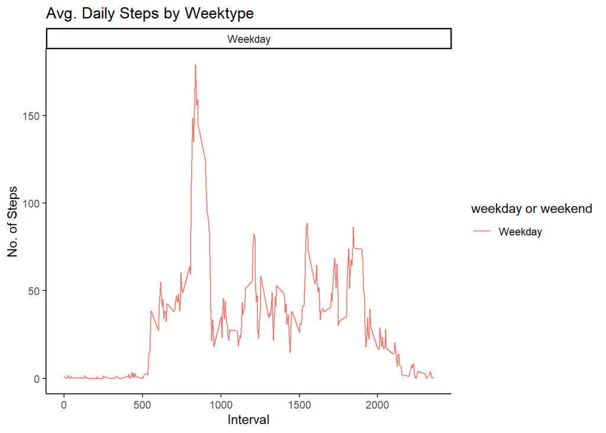

```r
# FIG 4
ggplot(IntervalDT , aes(x = interval , y = steps, color=`weekday or weekend`)) + geom_line() + labs(title = "Avg. Daily Steps by Weektype", x = "Interval", y = "No. of Steps") + facet_wrap(~`weekday or weekend` , ncol = 2, nrow=2) +
  theme_classic()
```